# Transcriptomics-Seurat Workflow-GSE111672

Daniela Q. Transcriptomics Course

Dataset: GSE111672. Pancreatic ductal adenocarcinoma. This analysis focuses on one of the two samples in this study

Install Necessary Packages

```r
install.packages('patchwork')
```

```r
library(dplyr)
library(Seurat)
library(patchwork)
```

```r
library(ggplot2)
```

Load the TSV file

```r
data=read.table(file = '/Users/danielaquijano/Documents/GitHub/Transcriptomics-Course-Projects/source_files/GSM3036909.tsv', sep = '\t', header = TRUE)
```

```r
PDAC.seurat.obj <- CreateSeuratObject(counts = data, project = "PDAC", min.cells = 3, min.features = 200)
```

Label Mitochondrial genes

```r
PDAC.seurat.obj[["percent.mt"]] <- PercentageFeatureSet(PDAC.seurat.obj, pattern = "^MT-")
head(PDAC.seurat.obj@meta.data)
```

|  | orig.ident | nCount_RNA | nFeature_RNA | percent.mt |
| --- | --- | --- | --- | --- |
| cell_091.133 | cell | 32176 | 1993 | 0 |
| cell_177.113 | cell | 14320 | 4329 | 0 |
| cell_289.088 | cell | 12684 | 4018 | 0 |
| cell_205.268 | cell | 15776 | 4394 | 0 |
| cell_162.063 | cell | 13153 | 3610 | 0 |
| cell_183.039 | cell | 12191 | 3844 | 0 |

View the number of counts, number of features, and the percent mitochondrial genes.

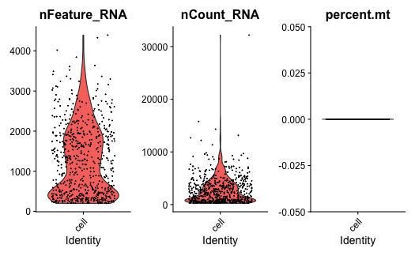

```r
VlnPlot(PDAC.seurat.obj, features = c("nFeature_RNA", "nCount_RNA", "percent.mt"), ncol = 3)
```

Keep the cells that have greater than 200 and less than 2500 unique features and the percent mitochondrial genes is less than 5.

```r
PDAC.seurat.obj <- subset(PDAC.seurat.obj, subset = nFeature_RNA > 200 & nFeature_RNA < 2500 &  percent.mt < 5)
```

Normalize data using the LogNormaliza method with a scale factor of 10,000

```r
#Normalize Data
PDAC.seurat.obj  <- NormalizeData(
  PDAC.seurat.obj,
  normalization.method = "LogNormalize",
  scale.factor = 10000,
  verbose = TRUE, )
str(PDAC.seurat.obj)
```

[output not shown]

Find the 2000 most variable genes using the FindVariableFeatures command using the vst method.

```r
PDAC.seurat.obj <- FindVariableFeatures(PDAC.seurat.obj, selection.method = "vst", nfeatures = 2000)
```

Scale data to normalize the standard deviation and center the data.

```r
all.genes <- rownames(PDAC.seurat.obj)
PDAC.seurat.obj <- ScaleData(PDAC.seurat.obj, features = all.genes)
```

Perform Principal Component Analysis

```r
PDAC.seurat.obj <- RunPCA(PDAC.seurat.obj, features = VariableFeatures(object = PDAC.seurat.obj))
```

```
PC_ 1
Positive:  10739, 16259, 17298, 12924, 16984, 848, 17119, 4983, 10736, 7262
       16289, 10370, 2092, 16770, 17117, 1378, 5227, 6798, 14234, 1418
       4231, 15868, 14850, 5207, 5634, 18411, 4246, 10733, 926, 2568
Negative:  16361, 9246, 18258, 1111, 9683, 9307, 15640, 6540, 1967, 1513
       14860, 16249, 7549, 13794, 4106, 14859, 3259, 8503, 6269, 14333
       1620, 6271, 4291, 4483, 18665, 14905, 6263, 17673, 18877, 875
PC_ 2
Positive:  6649, 2011, 4481, 16446, 7543, 4478, 14860, 7542, 14859, 8253
       3133, 3134, 4291, 3135, 13440, 4480, 3904, 1111, 10372, 8277
       3825, 13513, 6541, 6317, 3132, 17872, 3214, 12955, 9556, 3268
Negative:  7778, 7777, 15840, 7776, 7774, 7770, 10589, 3271, 3202, 7773
       7772, 2446, 4286, 7771, 2447, 2449, 7775, 7220, 17134, 16471
       6267, 13635, 4413, 7767, 3250, 11394, 7277, 10587, 1415, 10584
PC_ 3
Positive:  4036, 4009, 9714, 4035, 12925, 3135, 5766, 17245, 15201, 8277
       10251, 3268, 9045, 17905, 6587, 4670, 9044, 4192, 12406, 13440
       7459, 13105, 14851, 7070, 1999, 18665, 14853, 10246, 14446, 3224
Negative:  4231, 10739, 15183, 4983, 9758, 14234, 16984, 6798, 1378, 4246
       17119, 16082, 15289, 16289, 16259, 10736, 6320, 6540, 5971, 18411
       1076, 14860, 17117, 14859, 1967, 2627, 2568, 4291, 6271, 4478
PC_ 4
Positive:  3135, 3268, 8277, 13440, 7459, 7070, 3224, 14323, 3258, 8991
       8990, 3280, 19630, 3214, 5766, 9292, 7460, 15452, 16275, 8989
       18939, 102, 4425, 11249, 18938, 3247, 3246, 7212, 5243, 3267
Negative:  14863, 14860, 14859, 6649, 6540, 2011, 13755, 9045, 16446, 4481
       9714, 4009, 4035, 4291, 4478, 9044, 5566, 6593, 8259, 1967
       17905, 6272, 10251, 7738, 15201, 1447, 3287, 4192, 10372, 8253
PC_ 5
Positive:  3135, 3268, 8277, 7459, 13440, 7070, 3224, 3133, 16524, 8991
       8990, 19630, 3280, 13794, 9307, 16289, 4097, 5227, 8482, 9683
       16361, 18939, 8995, 15452, 18938, 4483, 7212, 3258, 3134, 4425
Negative:  2136, 15317, 7910, 1881, 9556, 9722, 1311, 16250, 8729, 2978
       15318, 3676, 4101, 11551, 18015, 7608, 9452, 4950, 7294, 12990
       14327, 8709, 3689, 13754, 16610, 13716, 8898, 7548, 755, 1894
```

```r
# visualize PCA results
print(PDAC.seurat.obj[["pca"]], dims = 1:10)
```

```
PC_ 1
Positive:  10739, 16259, 17298, 12924, 16984, 848, 17119, 4983, 10736, 7262
       16289, 10370, 2092, 16770, 17117, 1378, 5227, 6798, 14234, 1418
Negative:  16361, 9246, 18258, 1111, 9683, 9307, 15640, 6540, 1967, 1513
       14860, 16249, 7549, 13794, 4106, 14859, 3259, 8503, 6269, 14333
PC_ 2
Positive:  6649, 2011, 4481, 16446, 7543, 4478, 14860, 7542, 14859, 8253
       3133, 3134, 4291, 3135, 13440, 4480, 3904, 1111, 10372, 8277
Negative:  7778, 7777, 15840, 7776, 7774, 7770, 10589, 3271, 3202, 7773
       7772, 2446, 4286, 7771, 2447, 2449, 7775, 7220, 17134, 16471
PC_ 3
Positive:  4036, 4009, 9714, 4035, 12925, 3135, 5766, 17245, 15201, 8277
       10251, 3268, 9045, 17905, 6587, 4670, 9044, 4192, 12406, 13440
Negative:  4231, 10739, 15183, 4983, 9758, 14234, 16984, 6798, 1378, 4246
       17119, 16082, 15289, 16289, 16259, 10736, 6320, 6540, 5971, 18411
PC_ 4
Positive:  3135, 3268, 8277, 13440, 7459, 7070, 3224, 14323, 3258, 8991
       8990, 3280, 19630, 3214, 5766, 9292, 7460, 15452, 16275, 8989
Negative:  14863, 14860, 14859, 6649, 6540, 2011, 13755, 9045, 16446, 4481
       9714, 4009, 4035, 4291, 4478, 9044, 5566, 6593, 8259, 1967
PC_ 5
Positive:  3135, 3268, 8277, 7459, 13440, 7070, 3224, 3133, 16524, 8991
       8990, 19630, 3280, 13794, 9307, 16289, 4097, 5227, 8482, 9683
Negative:  2136, 15317, 7910, 1881, 9556, 9722, 1311, 16250, 8729, 2978
       15318, 3676, 4101, 11551, 18015, 7608, 9452, 4950, 7294, 12990
PC_ 6
Positive:  7910, 2136, 3676, 1881, 13930, 5533, 16250, 7548, 9722, 13754
       4101, 8898, 15317, 1311, 13980, 5252, 12990, 1296, 18015, 14859
Negative:  16170, 10359, 13189, 4392, 2068, 6446, 8182, 3, 8180, 4024
       4033, 4144, 16171, 15208, 15839, 8038, 3349, 14069, 17136, 2468
PC_ 7
Positive:  2447, 2446, 1893, 9045, 7774, 7775, 4286, 7772, 2449, 7220
       10589, 10584, 3202, 1415, 7776, 17873, 17134, 6684, 10587, 12918
Negative:  16170, 7597, 1435, 12402, 15839, 8182, 17490, 17213, 16487, 4026
       16171, 10359, 13033, 3349, 14085, 14069, 14013, 8257, 17827, 8180
PC_ 8
Positive:  17490, 6771, 17819, 4136, 17818, 6824, 10582, 8257, 15515, 8898
       8660, 8521, 15399, 11037, 8282, 1473, 3267, 6636, 5252, 4245
Negative:  11635, 3144, 17749, 18295, 12999, 10305, 3749, 13405, 3514, 3323
       3472, 13982, 17827, 18324, 1877, 18000, 3153, 12378, 1701, 1276
PC_ 9
Positive:  16170, 10359, 2721, 13189, 4392, 2068, 16973, 1418, 8180, 16119
       9692, 4026, 5252, 3349, 14046, 16171, 2141, 12970, 10079, 8178
Negative:  17818, 17819, 10582, 6824, 4136, 15515, 6771, 15399, 17490, 8898
       8660, 13754, 2247, 13411, 715, 17820, 3220, 4245, 15717, 11522
PC_ 10
Positive:  13466, 1571, 14853, 8219, 13440, 10251, 2627, 13301, 16524, 7460
       10349, 15528, 15452, 6320, 5541, 3789, 4246, 6782, 10246, 1849
Negative:  4136, 17818, 6824, 17490, 6771, 10582, 17819, 15399, 15515, 12999
       17749, 3514, 11635, 3472, 13930, 18295, 10305, 16543, 3749, 13754
```

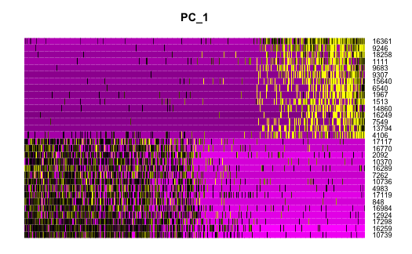

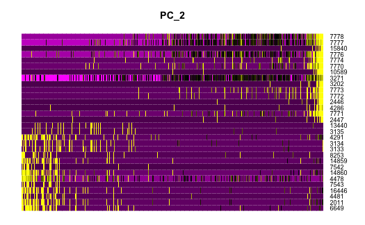

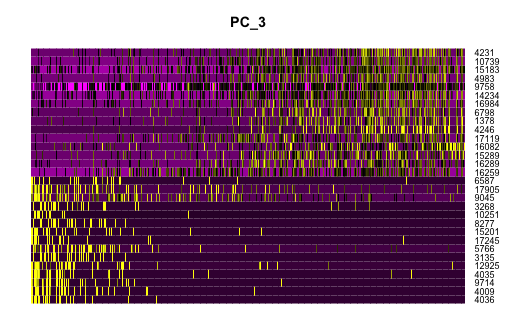

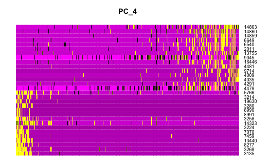

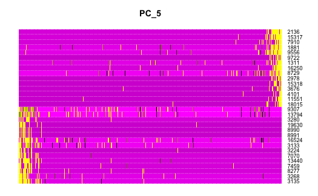

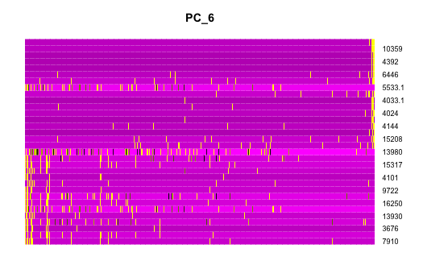

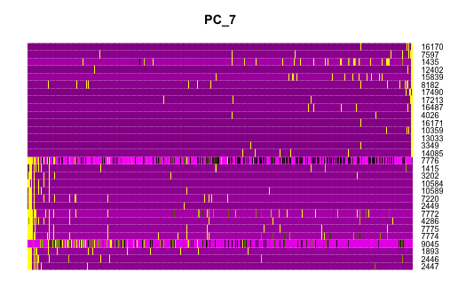

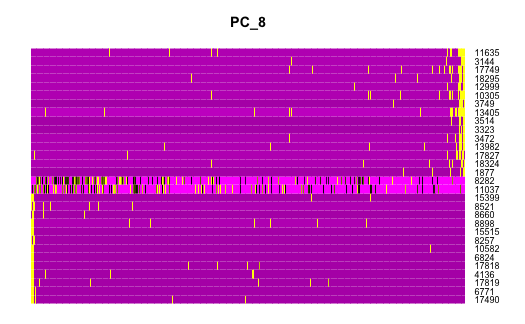

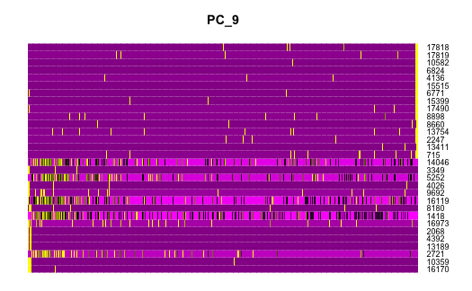

```r
for (i in 1:10) {
  i=DimHeatmap(PDAC.seurat.obj, dims = i, cells = 500, balanced = TRUE)
  i=i+(i-1)
}
```

[figure not shown]

```r
NA
```

Visualize data using VizDimLoadings and DimPlot functions. Can you tell from the PCA analyis, the number of cell types that are present?

```r
VizDimLoadings(PDAC.seurat.obj, dims = 1:2, reduction = "pca")
```

[output not shown]

```r
VizDimLoadings(PDAC.seurat.obj, dims = 3:4, reduction = "pca")
```

[output not shown]

```r
VizDimLoadings(PDAC.seurat.obj, dims = 5:6, reduction = "pca")
```

[output not shown]

```r
VizDimLoadings(PDAC.seurat.obj, dims = 7:8, reduction = "pca")
```

[output not shown]

```r
VizDimLoadings(PDAC.seurat.obj, dims = 9:10, reduction = "pca")
```

[output not shown]

```r
DimPlot(PDAC.seurat.obj, reduction = "pca")
```

[output not shown]

Find when does the variation reaches the lowest amount of variation explained. Using the JackStraw method with 100 replicates and score the first 20 dimensions.

```r
PDAC.seurat.obj <- JackStraw(PDAC.seurat.obj, num.replicate = 100)
PDAC.seurat.obj <- ScoreJackStraw(PDAC.seurat.obj, dims = 1:20)
```

Plot the results for the first 20 dimensions.

```r
JackStrawPlot(PDAC.seurat.obj, dims = 1:20)
```

[output not shown]

Use the elbow plot

```r
ElbowPlot(PDAC.seurat.obj)
```

[output not shown]

Group together the cells based on where they are located in the different dimensions. Use the FindNeighbors function using the first 9 dimensions.

```r
# 7. Clustering ------------
PDAC.seurat.obj<- FindNeighbors(PDAC.seurat.obj, dims = 1:9)
```

Identify the clusters usng the FindClusters function.

```r
PDAC.seurat.obj <- FindClusters(PDAC.seurat.obj)
head(PDAC.seurat.obj@meta.data)
```

[output not shown]

Perform a UMAP analysis using the first 9 dimensions using RunUMAP and then visualize it using DimPlot.

```r
PDAC.seurat.obj <- RunUMAP(PDAC.seurat.obj, dims = 1:9)

DimPlot(PDAC.seurat.obj, reduction = "umap")
```

[output not shown]

Identify the markers that compare each cluster against all. Report only positively markers (only.pos=TRUE). Using FindAllMarkers.

```r
PDAC.markers <- FindAllMarkers(PDAC.seurat.obj, only.pos = TRUE, min.pct = 0.25, logfc.threshold = 0.25)
PDAC.markers %>% group_by(cluster) %>% top_n(n = 2, wt = avg_log2FC)
```

[output not shown]

Create a violin plot using one feature from each cluster.

```r
genes_list = c("16289", "10632","4231","6649", "12925","3135","7771", "2136")
```

```r
VlnPlot(PDAC.seurat.obj, features=c("16289", "10632","4231"))
```

[output not shown]

```r
VlnPlot(PDAC.seurat.obj, features=c("6649", "12925","3135"))
```

[output not shown]

```r
VlnPlot(PDAC.seurat.obj, features=c("7771", "2136"))
```

[output not shown]

Create a feature plot using the same features as before.

```r
FeaturePlot(PDAC.seurat.obj, features=c("16289", "10632","4231"))
```

[output not shown]

```r
FeaturePlot(PDAC.seurat.obj, features=c("6649", "12925","3135"))
```

[output not shown]

```r
FeaturePlot(PDAC.seurat.obj, features=c("7771", "2136"))
```

[output not shown]